# Group Project

Deforestation, Group 41: Koh Yi Jing, Tan Shi Hui Cheryl, Wang Tingyu Kelly, Yang Shu Ting

2023-04-14

## 1. Introduction

Forests are vital – they filter the air we breathe, slow down climate change and are home to a wide variety of flora and fauna (WWF, 2023). To address the pressing issue of deforestation, we will be exploring the past trends of deforestation and their associated uses, by analysing observations from the year 1990 to 2015. We want to understand if vegetable oil production contributes significantly to deforestation, and uncover the top reasons for deforestation in the top contributing country. The visualisations obtained from these questions will further allow us to decipher the industries impacting deforestation rates the most, and target future efforts specifically towards these to solve the issue of deforestation effectively.

## 2. Descriptive statistics

```r
library(tidytuesdayR)
library(tidyverse)
library(ggthemes)
library(viridis)

data = tt_load("2021-04-06")
forest = data$forest
forest_area = data$forest_area
brazil_loss = data$brazil_loss
soybean_use = data$soybean_use
vegetable_oil = data$vegetable_oil
```

```r
forest = forest %>%
  filter(entity != "World") %>%
  drop_na(code)

forest_area = forest_area %>%
  filter(entity != "World") %>%
  drop_na(code) %>%
  mutate(forest_area = format(forest_area, scientific = FALSE)) %>%
  mutate_at(vars(forest_area), as.numeric) %>%
  mutate_at(vars(forest_area), round, digits = 2)

brazil_loss = brazil_loss %>%
  gather(`commercial_crops`:`small_scale_clearing`,key = "reason",value = "value")

soybean_use = soybean_use %>%
  filter(entity != "World") %>%
  drop_na(code) %>%
  gather(`human_food`:`processed`,key = "usage",value = "value") %>%
  replace(is.na(.), 0)

vegetable_oil = vegetable_oil %>%
  filter(entity != "World") %>%
  drop_na(code) %>%
  replace(is.na(.), 0)
```

```r
summary(forest)
```

```
##     entity              code                year      net_forest_conversion
##  Length:463         Length:463         Min.   :1990   Min.   :-3950790
##  Class :character   Class :character   1st Qu.:2000   1st Qu.:  -30130
##  Mode  :character   Mode  :character   Median :2010   Median :       0
##                                        Mean   :2004   Mean   :  -29461
##                                        3rd Qu.:2015   3rd Qu.:    3440
##                                        Max.   :2015   Max.   : 2360980
```

```r
n_distinct(forest$entity)
```

```
## [1] 129
```

```r
summary(forest_area)
```

```
##     entity              code                year       forest_area
##  Length:6743        Length:6743        Min.   :1990   Min.   : 0.0000
##  Class :character   Class :character   1st Qu.:1998   1st Qu.: 0.0000
##  Mode  :character   Mode  :character   Median :2005   Median : 0.0400
##                                        Mean   :2005   Mean   : 0.4495
##                                        3rd Qu.:2013   3rd Qu.: 0.2200
##                                        Max.   :2020   Max.   :20.0900
```

```r
n_distinct(forest_area$entity)
```

```
## [1] 223
```

```r
summary(soybean_use)
```

```
##     entity              code                year         usage
##  Length:24330       Length:24330       Min.   :1961   Length:24330
##  Class :character   Class :character   1st Qu.:1975   Class :character
##  Mode  :character   Mode  :character   Median :1989   Mode  :character
##                                        Mean   :1988
##                                        3rd Qu.:2001
##                                        Max.   :2013
##      value
##  Min.   :       0
##  1st Qu.:       0
##  Median :       0
##  Mean   :  236469
##  3rd Qu.:    3000
##  Max.   :59162000
```

```r
n_distinct(soybean_use$entity)
```

```
## [1] 172
```

```r
summary(vegetable_oil)
```

```
##     entity              code                year        crop_oil
##  Length:120497      Length:120497      Min.   :1961   Length:120497
##  Class :character   Class :character   1st Qu.:1975   Class :character
##  Mode  :character   Mode  :character   Median :1989   Mode  :character
##                                        Mean   :1989
##                                        3rd Qu.:2002
##                                        Max.   :2014
##    production
##  Min.   :       0
##  1st Qu.:       0
##  Median :       0
##  Mean   :   30428
##  3rd Qu.:     552
##  Max.   :29278200
```

```r
n_distinct(vegetable_oil$entity)
```

```
## [1] 197
```

```r
summary(brazil_loss)
```

```
##     entity              code                year         reason
##  Length:143         Length:143         Min.   :2001   Length:143
##  Class :character   Class :character   1st Qu.:2004   Class :character
##  Mode  :character   Mode  :character   Median :2007   Mode  :character
##                                        Mean   :2007
##                                        3rd Qu.:2010
##                                        Max.   :2013
##      value
##  Min.   :      0
##  1st Qu.:  13000
##  Median :  44000
##  Mean   : 226287
##  3rd Qu.: 157500
##  Max.   :2761000
```

## 3. Question 1

### Introduction

We want to investigate whether vegetable oil production has contributed to deforestation significantly using the `forest`,`forest_area` and `vegetable_oil` datasets. To answer this question, we want to focus on soybean oil production first, since soybean is one of the main types of vegetable oil. We are interested in this question because soy has been notorious for its links to deforestation due to the nature of its growth cycle. Soy can only produce very limited yield per cycle and it is unresponsive to fertilisers (Scorfield, 2021), thus leading to scarcity in soy production. Therefore more land is required to grow soy, potentially resulting in deforestation. Then we will compare the general trend of vegetable oil production with respect to deforestation.

### Methodology

For the first plot, we are investigating the relationship between the amount of soybean oil produced and the percentage of global forest area. We filtered out the top 5 soybean oil producing countries in 2014, since 2014 is the latest data available and these countries are more likely to have contributed to global deforestation significantly. We plotted the percentage of forest area of the top 5 countries against soybean oil production from 1990 to 2014, to see whether the two variables are positively or negatively correlated.

For the first subplot in the second plot, we are plotting the time-series of vegetable oil production by types, from 1990 to 2014. The vegetable oil production is categorised into 3 types, which are palm, soybean, and rapeseed, since these are the top 3 types of crops for vegetable oil production. For the second subplot, we are plotting the amount of forest lost globally from 1990 to 2015. Putting these two subplots together allows us to compare the global trends of vegetable oil production, especially soybean oil production, and deforestation across years.

### Visualizations

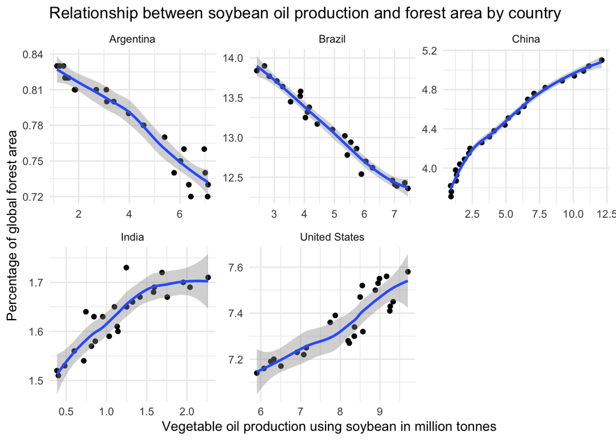

```r
soybean_oil = vegetable_oil %>%
  filter(crop_oil == "Soybean")

soybean_top5 = soybean_oil %>%
  filter(year == 2014) %>%
  arrange(desc(production)) %>%
  head(5) %>%
  pull(entity)

forest_area_top5_soybean = forest_area %>%
  left_join(soybean_oil, by = c("entity", "code", "year")) %>%
  filter(entity %in% soybean_top5) %>%
  drop_na(production) %>%   # 2015-2020 missing oil production
  mutate(production = production/1000000)

ggplot(forest_area_top5_soybean, aes(x = production, y = forest_area)) +
  geom_point() +
  labs(x = "Vegetable oil production using soybean in million tonnes", y = "Percentage of global forest area",
       title = "Relationship between soybean oil production and forest area by country") +
  facet_wrap(~ entity, scales = "free") +
  geom_smooth() +
  theme_minimal()
```

```r
vegetable_oil %>%
  group_by(crop_oil) %>%
  summarize(total = sum(production)) %>%
  arrange(desc(total)) %>%
  head(3)
```

```
## # A tibble: 3 × 2
##   crop_oil      total
##   <chr>         <dbl>
## 1 Soybean  1001525199
## 2 Palm      873581506
## 3 Rapeseed  477294130
```

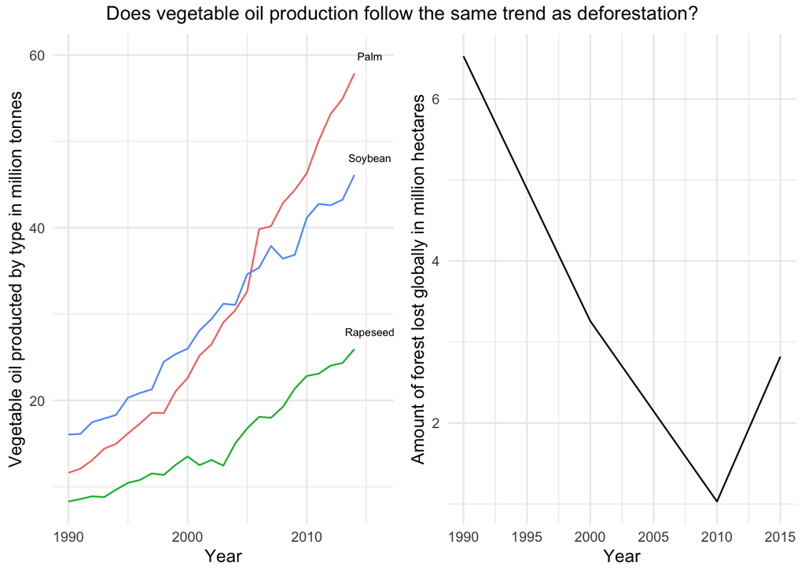

```r
world_soybean_oil = soybean_oil %>%
  filter(year >= 1990) %>%
  group_by(year) %>%
  summarize(total = sum(production))

world_palm_oil = vegetable_oil %>%
  filter(crop_oil == "Palm", year >= 1990) %>%
  group_by(year) %>%
  summarize(total = sum(production))

world_rapeseed_oil = vegetable_oil %>%
  filter(crop_oil == "Rapeseed", year >= 1990) %>%
  group_by(year) %>%
  summarize(total = sum(production))

world_oil = world_soybean_oil %>%
  left_join(world_palm_oil, by = "year") %>%
  rename(Soybean = total.x, Palm = total.y) %>%
  left_join(world_rapeseed_oil, by = "year") %>%
  rename(Rapeseed = total) %>%
  gather(`Soybean`:`Rapeseed`, key = type, value = production)

# prepare for texts on the plot
text = world_oil %>%
  filter(year == 2014)

p1 = ggplot(data = world_oil) +
  geom_line(aes(x = year, y = production/1000000, color = type)) +
  geom_text(data = text, aes(x = 2015, y = production/1000000, label = type),
            nudge_x = 0.3, nudge_y = 2, size = 2.4) +
  xlim(1990, 2016) +
  labs(x = "Year", y = "Vegetable oil producted by type in million tonnes") +
  scale_color_discrete(guide = "none") +
  theme_minimal()

world_deforestation = forest %>%
  group_by(year) %>%
  summarize(total = -sum(net_forest_conversion))

p2 = ggplot(data = world_deforestation, aes(x = year, y = total/1000000)) +
  geom_line() +
  labs(x = "Year", y = "Amount of forest lost globally in million hectares") +
  theme_minimal()

library(gridExtra)
library(grid)
grid.arrange(p1, p2, nrow = 1,
             top = textGrob("Does vegetable oil production follow the same trend as deforestation?"))
```

### Discussions

The amount of soybean oil production and the percentage of global forest area are positively correlated for China, India, and the United States, while that of Argentina and Brazil are negatively correlated. The negative correlation could be the result of increasing soybean oil production, which means that more land has to be cleared for production, leading to less forest area. On the other hand, the positive correlation may mean that growing soybean oil production does not contribute significantly to deforestation in China, India, and the US. This could be due to the rates of natural forest expansion and afforestation being significantly higher than the deforestation rates.

We further investigate the trends of soybean oil production and deforestation on a global level. From the plot, we can see that soybean oil production increased over the years, while the amount of forest lost globally decreased from 1990 to 2010, which aligns with the positive correlation we observed for China, India, and the US. However, the amount of forest lost globally increased from 2010 to 2015, which aligns with the negative correlation we observed for Argentina and Brazil. Since palm and rapeseed oil production have a similar trend as soybean oil production, it means that vegetable oil production in general may not have contributed significantly to deforestation as the amount of vegetable oil produced increased while forest loss decreased from 1990 to 2010. Hence, there might be other factors that contribute significantly to forest loss.

## Question 2

### Introduction

We are interested in determining the top contributing countries for deforestation. This is important to know such that in future, more efficient and specific measures could be put into place to target these root causes and industries. This would be done through investigating the top 5 deforestation reasons of the country with the highest deforestation area and exploring the trends and consistency of these causes. To do this, we would be using the `forest` dataset to determine the country with the highest deforestation rates and consequently, using the `brazil_loss` dataset to zoom in on the reasons specifically in the country with the highest deforestation rates.

### Methodology

Firstly, we will plot the area of forest lost for the top 5 countries with highest deforestation area against time, from 1990 to 2015 in a line graph. We derive the top 5 countries from the sum of net forest conversion over the years in the forest dataset. From the plot, we will identify the country with the highest net forest loss for further investigation of deforestation causes.

### Visualizations

```r
top5countries = forest %>%
  select(entity, net_forest_conversion) %>%
  group_by(entity) %>%
  summarize(total = sum(net_forest_conversion)) %>%
  arrange(total) %>%
  ungroup() %>%
  head(5) %>%
  pull(entity)
top5countries
```

```
## [1] "Brazil"    "Indonesia" "Tanzania"  "Myanmar"   "Paraguay"
```

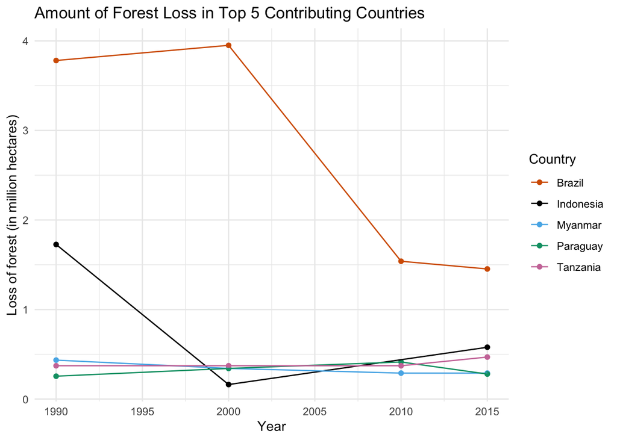

```r
df = forest %>% rename(Country = entity) %>%
  filter(Country %in% top5countries)

ggplot(data = df,aes(year,-net_forest_conversion/1000000,color = Country)) +
  geom_point() +
  geom_line() +
  labs(x = "Year",y = "Loss of forest (in million hectares)",title = "Amount of Forest Loss in Top 5 Contributing Countries",fill = "Country") +
  scale_color_manual(values = c("#D55E00", "#000000",
           "#56B4E9","#009E73" , "#CC79A7")) +
  theme(plot.title = element_text(hjust = 0.6)) +
  theme_minimal()
```

```r
top5reasons = brazil_loss %>%
  select(reason, value) %>%
  group_by(reason) %>%
  summarize(reason = reason,total = sum(value), .groups = "drop") %>%
  arrange(-total) %>%
  unique() %>%
  head(5) %>%
  pull(reason)
top5reasons
```

```
## [1] "pasture"              "small_scale_clearing" "commercial_crops"
## [4] "fire"                 "selective_logging"
```

```r
df2 = brazil_loss %>%
  mutate(reason = (ifelse(!(reason %in% top5reasons), "Others", reason))) %>%
  mutate(reason= fct_reorder(reason, -value))
levels(df2$reason)
```

```
## [1] "pasture"              "small_scale_clearing" "commercial_crops"
## [4] "selective_logging"    "fire"                 "Others"
```

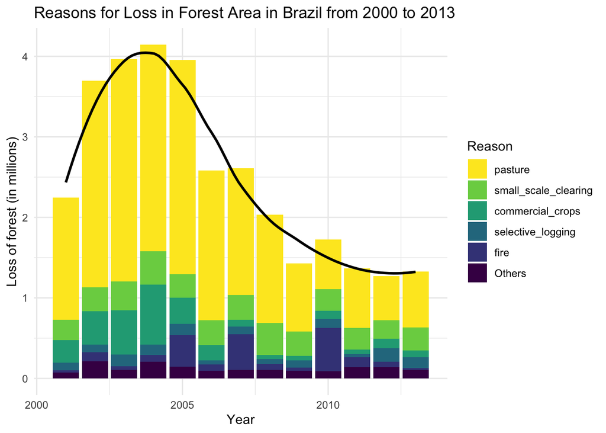

```r
df_total <- df2 %>%
  group_by(year) %>%
  summarise(total_loss = sum(value))

# Plot the data with a stacked bar chart and a separate line for the total
options(scipen = 999)
ggplot(data = df2,aes(year, value/1000000))+
  geom_col(aes(fill = reason)) +
  scale_fill_discrete(name = "Reason") +
  geom_smooth(data = df_total, aes(year, total_loss/1000000), color = "black", se = FALSE) +
  scale_fill_viridis(discrete = TRUE, direction = -1)+
  labs(x = "Year",y = "Loss of forest (in millions)",title = "Reasons for Loss in Forest Area in Brazil from 2000 to 2013",fill = "Reason") +
  theme(plot.title = element_text(hjust = 1.5)) +
  theme_minimal()
```

### Discussions

From the first plot, it is illustrated that the forest area lost in Brazil is consistently, and significantly higher than the other 4 countries in the plot. Despite the sharp decrease in forest loss in Brazil after 2000, its deforestation rates still stayed significantly above the rest. This is not surprising because the Amazon rainforest has suffered from severe deforestation and 60% of the Amazon forest is in Brazil (Genin, 2021). Hence, Brazil’s deforestation patterns and causes should be explored in greater depth. This is consequently done in our second plot.

## 5. Reference

https://github.com/rfordatascience/tidytuesday/blob/master/data/2021/2021-04-06/readme.md

WWF. (2023). The importance of forests. WWF. Retrieved April 14, 2023, from https://wwf.panda.org/discover/our_focus/forests_practice/importance_forests/

Scorfield, H. (2021, October 19). Ethical debates: Is soy bad for the environment? ♻CW. Commercial Waste. Retrieved April 14, 2023, from https://commercialwaste.trade/ethical-debates-soy-bad-environment-commercial-waste/#:~:text=The%20leading%20cause%20for%20this,continuously%20growing%20demand%20for%20soy

Genin, C., Calixto, B., Walls, G., Keneally, S., Frasson, C., & Vicente, I. (2021, September 3). How can Brazil protect the Amazon and advance climate action? World Resources Institute. Retrieved April 14, 2023, from https://www.wri.org/insights/strategies-amazon-rainforest-climate-action-brazil

Carvalho. (2020). Attractiveness of cattle farming in Brazil. Center for Advanced Studies on Applied Economics. Retrieved April 14, 2023, from https://www.cepea.esalq.usp.br/en/opinion/attractiveness-of-cattle-farming-in-brazil.aspx

Butler, R. A. (2021, November 22). Deforestation in the Amazon. Mongabay. Retrieved April 14, 2023, from https://rainforests.mongabay.com/amazon/amazon_destruction.html